# IODS course project

Patrik Lauha

# Introduction to Open Data Science - Course Project

# About the project

At the beginning of the course I am feeling a little bit tired, since I am currently a little bit busy with other projects. I have used R and RStudio before and should be mostly familiar with them, but this course works as a good reminder for me. I found this course from the list of possible courses to include in my doctoral studies.

The R for Health Data Science book seems very clear and well-organized and I believe that it offers a good way to learn R also for people who are not familiar with R before. I have not used tibbles or piping before in R, so it was nice to learn about them.

#### Here is a link to my GitHub repo:

[GitHub-link](https://github.com/plauha/IODS-project)

```r
# This is a so-called "R chunk" where you can write R code.

1+1
```

```
## [1] 2
```

```r
date()
```

```
## [1] "Mon Dec 11 14:28:17 2023"
```

# Chapter 2

This week I got to remind myself about fitting linear models and interpreting their results in R as well as preprocessing the data before the analysis. The analysis and the results are presented below.

```r
library(tidyverse)
data = read_csv('data/learning2014.csv')
str(data)
```

```
## spc_tbl_ [166 × 7] (S3: spec_tbl_df/tbl_df/tbl/data.frame)
##  $ gender  : chr [1:166] "F" "M" "F" "M" ...
##  $ Age     : num [1:166] 53 55 49 53 49 38 50 37 37 42 ...
##  $ Attitude: num [1:166] 3.7 3.1 2.5 3.5 3.7 3.8 3.5 2.9 3.8 2.1 ...
##  $ Deep    : num [1:166] 3.58 2.92 3.5 3.5 3.67 ...
##  $ Stra    : num [1:166] 3.38 2.75 3.62 3.12 3.62 ...
##  $ Surf    : num [1:166] 2.58 3.17 2.25 2.25 2.83 ...
##  $ Points  : num [1:166] 25 12 24 10 22 21 21 31 24 26 ...
##  - attr(*, "spec")=
##   .. cols(
##   ..   gender = col_character(),
##   ..   Age = col_double(),
##   ..   Attitude = col_double(),
##   ..   Deep = col_double(),
##   ..   Stra = col_double(),
##   ..   Surf = col_double(),
##   ..   Points = col_double()
##   .. )
##  - attr(*, "problems")=<externalptr>
```

```r
head(data)
```

```
## # A tibble: 6 × 7
##   gender   Age Attitude  Deep  Stra  Surf Points
##   <chr>  <dbl>    <dbl> <dbl> <dbl> <dbl>  <dbl>
## 1 F         53      3.7  3.58  3.38  2.58     25
## 2 M         55      3.1  2.92  2.75  3.17     12
## 3 F         49      2.5  3.5   3.62  2.25     24
## 4 M         53      3.5  3.5   3.12  2.25     10
## 5 M         49      3.7  3.67  3.62  2.83     22
## 6 F         38      3.8  4.75  3.62  2.42     21
```

The data contains information of 166 students of an university course. The data contains background information of students age and gender. Variables Attitude, Deep, Stra and Surf are averaged over several variables and describe the students overall attitude towards statistics, deep approach, strategic approach and surface approach for studying on a scale from 1 to 5. Variable Points contains the number of points student received in exam.

```r
library(psych)
```

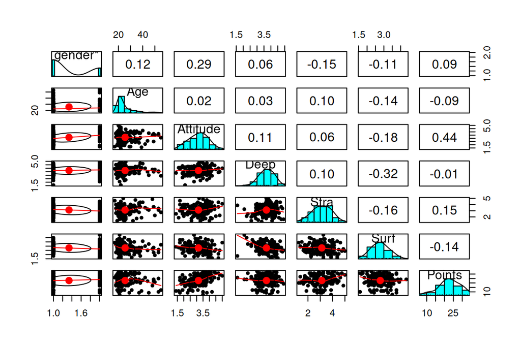

```r
pairs.panels(data, method = "pearson", density = TRUE)
```

```r
table(data$gender)
```

```
##
##   F   M
## 110  56
```

```r
mean(data$Age)
```

```
## [1] 25.51205
```

There were twice more women than men on the course. The average age of participants is 25.5 years and the age distribution is positively skewed as expected. Other variables seem to be roughly normally distributed. There are mostly no strong correlations between variables. The overall attitude towards statistics correlates positively with the exam points (r=0.44) and deep and surface study approaches correlate negatively (r=-0.32).

```r
model = lm(Points ~Attitude + Stra + Surf, data=data)
summary(model)
```

```
##
## Call:
## lm(formula = Points ~ Attitude + Stra + Surf, data = data)
##
## Residuals:
##      Min       1Q   Median       3Q      Max
## -17.1550  -3.4346   0.5156   3.6401  10.8952
##
## Coefficients:
##             Estimate Std. Error t value Pr(>|t|)
## (Intercept)  11.0171     3.6837   2.991  0.00322 **
## Attitude      3.3952     0.5741   5.913 1.93e-08 ***
## Stra          0.8531     0.5416   1.575  0.11716
## Surf         -0.5861     0.8014  -0.731  0.46563
## ---
## Signif. codes:  0 '***' 0.001 '**' 0.01 '*' 0.05 '.' 0.1 ' ' 1
##
## Residual standard error: 5.296 on 162 degrees of freedom
## Multiple R-squared:  0.2074, Adjusted R-squared:  0.1927
## F-statistic: 14.13 on 3 and 162 DF,  p-value: 3.156e-08
```

I chose Attitude, Strategic approach and Surface approach as explanatory variables to model the exam performance (=Points). Attitude seems to be the only statistically significant variable. Higher values of attitude indicate higher points in the exam. Strategic approach seems to have a positive effect and Surface approach a negative effect, but these explanatory variables are not statistically significant.

```r
model2 = lm(Points ~Attitude + Stra, data=data)
summary(model2)
```

```
##
## Call:
## lm(formula = Points ~ Attitude + Stra, data = data)
##
## Residuals:
##      Min       1Q   Median       3Q      Max
## -17.6436  -3.3113   0.5575   3.7928  10.9295
##
## Coefficients:
##             Estimate Std. Error t value Pr(>|t|)
## (Intercept)   8.9729     2.3959   3.745  0.00025 ***
## Attitude      3.4658     0.5652   6.132 6.31e-09 ***
## Stra          0.9137     0.5345   1.709  0.08927 .
## ---
## Signif. codes:  0 '***' 0.001 '**' 0.01 '*' 0.05 '.' 0.1 ' ' 1
##
## Residual standard error: 5.289 on 163 degrees of freedom
## Multiple R-squared:  0.2048, Adjusted R-squared:  0.1951
## F-statistic: 20.99 on 2 and 163 DF,  p-value: 7.734e-09
```

```r
model3 = lm(Points ~Attitude, data=data)
summary(model3)
```

```
##
## Call:
## lm(formula = Points ~ Attitude, data = data)
##
## Residuals:
##      Min       1Q   Median       3Q      Max
## -16.9763  -3.2119   0.4339   4.1534  10.6645
##
## Coefficients:
##             Estimate Std. Error t value Pr(>|t|)
## (Intercept)  11.6372     1.8303   6.358 1.95e-09 ***
## Attitude      3.5255     0.5674   6.214 4.12e-09 ***
## ---
## Signif. codes:  0 '***' 0.001 '**' 0.01 '*' 0.05 '.' 0.1 ' ' 1
##
## Residual standard error: 5.32 on 164 degrees of freedom
## Multiple R-squared:  0.1906, Adjusted R-squared:  0.1856
## F-statistic: 38.61 on 1 and 164 DF,  p-value: 4.119e-09
```

The model gets better, when Surface approach is removed from the explanatory variables. Strategic approach is almost statistically significant variable but still worth to include in the model, since adjusted R-squared is higher with it than without it. My final model is thus model2. Based on results of this model, both Attitude and Strategic approach have a positive effect on exam points. The dependency is stronger for Attitude. On average increase of one unit in Attitude increases exam result by 3.5 points and increase of one unit in Strategic approach increases exam result by 0.9 points (if other factors remain unchanged). The R^2 value of the model is 0.20, which means that Attitude and Strategic approach explain 20% of the variation of exam results. So the majority of the exam performance is still explained by some other factors than only the students’ attitude towards statistics and use of strategic approach.

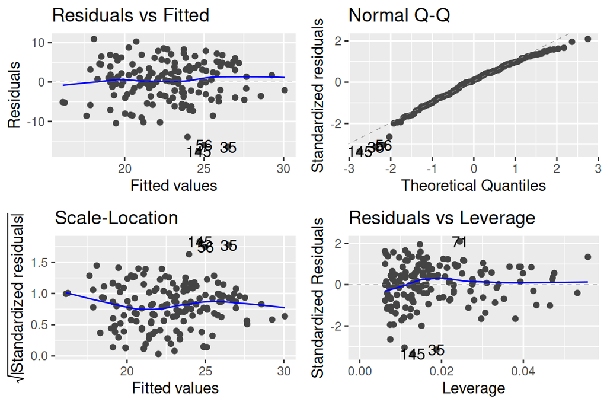

```r
library(ggfortify)
autoplot(model2)
```

In linear model the residuals should be randomly and roughly normally distributed around the prediction (i.e. there should not be any kind of dependence structure in the residuals). The Residuals vs Fitted plot shows that this indeed is the case. No dependence structure is evident and the residuals don’t seem to depend on fitted values. There are no major outliers. Normal Q-Q plot can be used to more carefully assess the normality assumption of the residuals. In ideal case the residuals should follow the diagonal dashed line. In this case this is not perfectly true, but still good enough so the normality assumption of residuals is not violated. Residuals vs Leverage plot can be used to assess the stability of the model. If removing a single observation would change the model coefficients significantly, (i.e. the data point would fall outside of the Cook’s distance in the residuals vs leverage plot), the results of the model would not be very reliable. In this model this is not the case and also residuals vs leverage plot seems to be in order.

# Chapter 3

The analysis and results of week 3 are presented below.

```r
library(tidyverse)
data = read_csv('data/student_all.csv', show_col_types = FALSE)
colnames(data)
```

```
##  [1] "school"     "sex"        "age"        "address"    "famsize"
##  [6] "Pstatus"    "Medu"       "Fedu"       "Mjob"       "Fjob"
## [11] "reason"     "guardian"   "traveltime" "studytime"  "schoolsup"
## [16] "famsup"     "activities" "nursery"    "higher"     "internet"
## [21] "romantic"   "famrel"     "freetime"   "goout"      "Dalc"
## [26] "Walc"       "health"     "failures.x" "paid.x"     "absences.x"
## [31] "G1.x"       "G2.x"       "G3.x"       "failures.y" "paid.y"
## [36] "absences.y" "G1.y"       "G2.y"       "G3.y"       "alc_use"
## [41] "high_use"
```

The data contains information of 370 students who have participated on a mathematics course and a portuguese course. 27 first variables contain background information of the students. Variable ‘failure’ contains the number of past class failures, ‘absence’ the number of absences, ‘paid’ if extra classes have been paid for the course and G1-G3 the grades for first and second period and in total, for Mathematics (x) and Portuguese (y) respectively. Variable ‘alc_use’ describes the alcohol consumption (1= very low, 5= very high) and ‘high_use’ indicates if alc_use > 2.

I study the relationship between high alcohol consumption and final grades and absences on both courses (G3.x, absences.x, G3.y, absences.y). I assume that high alcohol consumption might correlate with lower grades and greater number of absences.

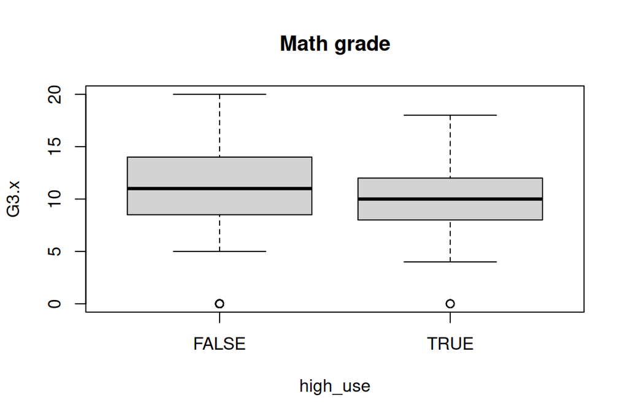

```r
boxplot(G3.x ~ high_use, data=data, main = "Math grade")
```

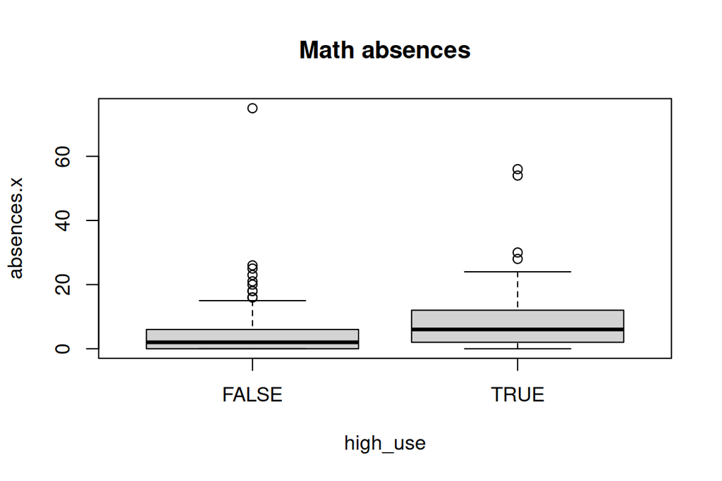

```r
boxplot(absences.x ~ high_use, data=data, main = "Math absences")
```

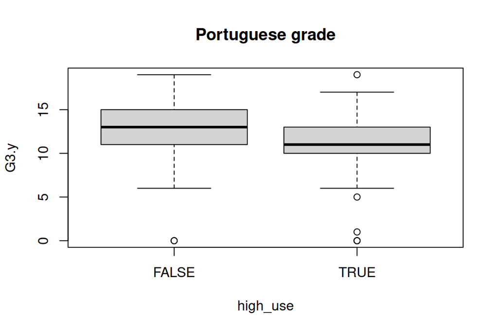

```r
boxplot(G3.y ~ high_use, data=data, main = "Portuguese grade")
```

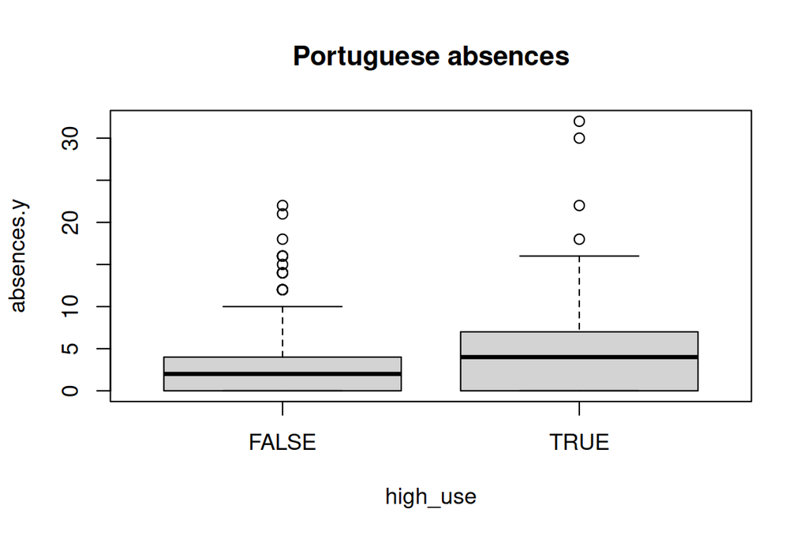

```r
boxplot(absences.y ~ high_use, data=data, main = "Portuguese absences")
```

```r
aggregate(data[, c('G3.x', 'absences.x', 'G3.y', 'absences.y')], list(data$high_use), mean)
```

```
##   Group.1     G3.x absences.x     G3.y absences.y
## 1   FALSE 10.60232   4.332046 12.99228   3.081081
## 2    TRUE 10.14414   7.828829 11.53153   4.918919
```

Based on the exploration, the initial hypothesis seems to be true. Grades for low_use group are slightly higher on both courses (10.6 vs 10.1 and 13.0 vs 11.5) and absences are lower (4.3 vs 7.8 and 3.1 vs 4.9).

I fit a logistic regression model to study the dependence between high alcohol usage and aforementioned four variables describing school performance. (Note that even though high alcohol usage is here used as a target variable and the school performance as explanatory variables, the model does not state anything about causality and in real world the possible causality between the variables might probably go the other way around!)

```r
model <- glm(high_use ~ G3.x+absences.x+G3.y+absences.y, data = data, family = binomial)
summary(model)
```

```
##
## Call:
## glm(formula = high_use ~ G3.x + absences.x + G3.y + absences.y,
##     family = binomial, data = data)
##
## Coefficients:
##             Estimate Std. Error z value Pr(>|z|)
## (Intercept)  0.67095    0.55309   1.213 0.225091
## G3.x         0.04636    0.03238   1.432 0.152172
## absences.x   0.04010    0.02028   1.977 0.048045 *
## G3.y        -0.19328    0.04970  -3.889 0.000101 ***
## absences.y   0.03921    0.02885   1.359 0.174194
## ---
## Signif. codes:  0 '***' 0.001 '**' 0.01 '*' 0.05 '.' 0.1 ' ' 1
##
## (Dispersion parameter for binomial family taken to be 1)
##
##     Null deviance: 452.04  on 369  degrees of freedom
## Residual deviance: 416.96  on 365  degrees of freedom
## AIC: 426.96
##
## Number of Fisher Scoring iterations: 4
```

```r
# Odds ratios and their confidence intervals:
exp(cbind(OR = coef(model), confint(model)))
```

```
##                    OR     2.5 %    97.5 %
## (Intercept) 1.9560973 0.6766933 5.9921960
## G3.x        1.0474534 0.9844994 1.1181947
## absences.x  1.0409158 1.0028173 1.0858484
## G3.y        0.8242486 0.7444620 0.9055192
## absences.y  1.0399855 0.9824006 1.1008298
```

Contradictory to the hypothesis and initial results, higher scores on math course seem to even indicate slightly higher probability of high alcohol usage. This is probably due to having too many explanatory variables, which are likely to have some amount of multicollinearity. It is very likely that there is correlation between absences and grade of a course, which slightly violates the independence assumption of a logistic regression model. It might be wise to remove some explanatory variables and try a simpler model.

```r
model2 <- glm(high_use ~ absences.x+G3.y, data = data, family = binomial)
summary(model2)
```

```
##
## Call:
## glm(formula = high_use ~ absences.x + G3.y, family = binomial,
##     data = data)
##
## Coefficients:
##             Estimate Std. Error z value Pr(>|z|)
## (Intercept)  0.81239    0.54258   1.497 0.134325
## absences.x   0.05702    0.01777   3.209 0.001333 **
## G3.y        -0.16092    0.04231  -3.803 0.000143 ***
## ---
## Signif. codes:  0 '***' 0.001 '**' 0.01 '*' 0.05 '.' 0.1 ' ' 1
##
## (Dispersion parameter for binomial family taken to be 1)
##
##     Null deviance: 452.04  on 369  degrees of freedom
## Residual deviance: 420.25  on 367  degrees of freedom
## AIC: 426.25
##
## Number of Fisher Scoring iterations: 4
```

```r
# Odds ratios and their confidence intervals:
exp(cbind(OR = coef(model2), confint(model2)))
```

```
##                    OR     2.5 %   97.5 %
## (Intercept) 2.2532861 0.7956532 6.754724
## absences.x  1.0586818 1.0246277 1.098323
## G3.y        0.8513564 0.7808634 0.922579
```

Now the model seems to be a little bit better. Let’s next predict for the data:

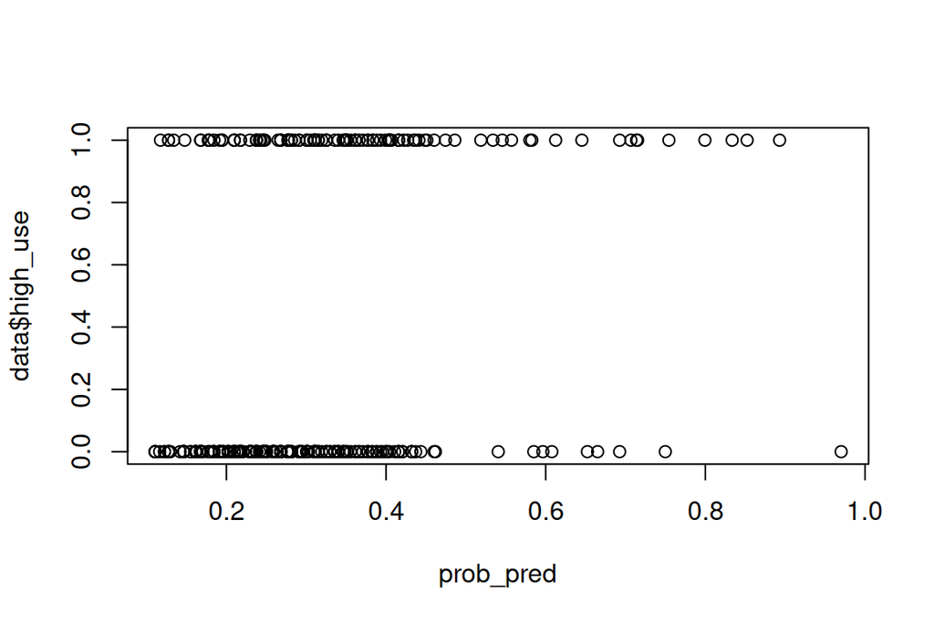

```r
prob_pred = model2 %>% predict(data, type = "response")
pred = prob_pred > 0.5
plot(prob_pred, data$high_use)
```

```r
table(pred, data$high_use)
```

```
##
## pred    FALSE TRUE
##   FALSE   250   94
##   TRUE      9   17
```

Ideally the true cases (high users) on the top of the plot should be located more on the right than the false cases (low users). My model does not seem to perform very well in predicting alcohol usage based on school performance. The table shows the predicted negatives versus positives. Prediction is shown on rows and true condition on columns. 250 out of 259 low users are correctly classifies as low users, but only 17 of 111 high users are classified as high users.

```r
mean(pred==data$high_use)
```

```
## [1] 0.7216216
```

```r
mean(data$high_use == FALSE)
```

```
## [1] 0.7
```

The prediction from my model is correct in 72% of the cases. Purely by guessing the most common value (high_use = FALSE) for each student we get to accuracy of 70% so the model does not seem to be very useful :’(

The Bonus exercises sound interesting but unfortunately I didn’t have time to complete them.. :(

# Chapter 4

The analysis and results of week 4 are presented below.

```r
library(MASS)
data(Boston)
#View(Boston)
```

The data set contains information of 506 areas in Boston including the median value of houses and 13 other variables, such as the crime rate, amount of air pollution, distance to employment centres and pupil-to-teacher ratio.

```r
summary(Boston)
```

```
##       crim                zn             indus            chas
##  Min.   : 0.00632   Min.   :  0.00   Min.   : 0.46   Min.   :0.00000
##  1st Qu.: 0.08205   1st Qu.:  0.00   1st Qu.: 5.19   1st Qu.:0.00000
##  Median : 0.25651   Median :  0.00   Median : 9.69   Median :0.00000
##  Mean   : 3.61352   Mean   : 11.36   Mean   :11.14   Mean   :0.06917
##  3rd Qu.: 3.67708   3rd Qu.: 12.50   3rd Qu.:18.10   3rd Qu.:0.00000
##  Max.   :88.97620   Max.   :100.00   Max.   :27.74   Max.   :1.00000
##       nox               rm             age              dis
##  Min.   :0.3850   Min.   :3.561   Min.   :  2.90   Min.   : 1.130
##  1st Qu.:0.4490   1st Qu.:5.886   1st Qu.: 45.02   1st Qu.: 2.100
##  Median :0.5380   Median :6.208   Median : 77.50   Median : 3.207
##  Mean   :0.5547   Mean   :6.285   Mean   : 68.57   Mean   : 3.795
##  3rd Qu.:0.6240   3rd Qu.:6.623   3rd Qu.: 94.08   3rd Qu.: 5.188
##  Max.   :0.8710   Max.   :8.780   Max.   :100.00   Max.   :12.127
##       rad              tax           ptratio          black
##  Min.   : 1.000   Min.   :187.0   Min.   :12.60   Min.   :  0.32
##  1st Qu.: 4.000   1st Qu.:279.0   1st Qu.:17.40   1st Qu.:375.38
##  Median : 5.000   Median :330.0   Median :19.05   Median :391.44
##  Mean   : 9.549   Mean   :408.2   Mean   :18.46   Mean   :356.67
##  3rd Qu.:24.000   3rd Qu.:666.0   3rd Qu.:20.20   3rd Qu.:396.23
##  Max.   :24.000   Max.   :711.0   Max.   :22.00   Max.   :396.90
##      lstat            medv
##  Min.   : 1.73   Min.   : 5.00
##  1st Qu.: 6.95   1st Qu.:17.02
##  Median :11.36   Median :21.20
##  Mean   :12.65   Mean   :22.53
##  3rd Qu.:16.95   3rd Qu.:25.00
##  Max.   :37.97   Max.   :50.00
```

```r
cor(Boston)
```

```
##                crim          zn       indus         chas         nox
## crim     1.00000000 -0.20046922  0.40658341 -0.055891582  0.42097171
## zn      -0.20046922  1.00000000 -0.53382819 -0.042696719 -0.51660371
## indus    0.40658341 -0.53382819  1.00000000  0.062938027  0.76365145
## chas    -0.05589158 -0.04269672  0.06293803  1.000000000  0.09120281
## nox      0.42097171 -0.51660371  0.76365145  0.091202807  1.00000000
## rm      -0.21924670  0.31199059 -0.39167585  0.091251225 -0.30218819
## age      0.35273425 -0.56953734  0.64477851  0.086517774  0.73147010
## dis     -0.37967009  0.66440822 -0.70802699 -0.099175780 -0.76923011
## rad      0.62550515 -0.31194783  0.59512927 -0.007368241  0.61144056
## tax      0.58276431 -0.31456332  0.72076018 -0.035586518  0.66802320
## ptratio  0.28994558 -0.39167855  0.38324756 -0.121515174  0.18893268
## black   -0.38506394  0.17552032 -0.35697654  0.048788485 -0.38005064
## lstat    0.45562148 -0.41299457  0.60379972 -0.053929298  0.59087892
## medv    -0.38830461  0.36044534 -0.48372516  0.175260177 -0.42732077
##                  rm         age         dis          rad         tax    ptratio
## crim    -0.21924670  0.35273425 -0.37967009  0.625505145  0.58276431  0.2899456
## zn       0.31199059 -0.56953734  0.66440822 -0.311947826 -0.31456332 -0.3916785
## indus   -0.39167585  0.64477851 -0.70802699  0.595129275  0.72076018  0.3832476
## chas     0.09125123  0.08651777 -0.09917578 -0.007368241 -0.03558652 -0.1215152
## nox     -0.30218819  0.73147010 -0.76923011  0.611440563  0.66802320  0.1889327
## rm       1.00000000 -0.24026493  0.20524621 -0.209846668 -0.29204783 -0.3555015
## age     -0.24026493  1.00000000 -0.74788054  0.456022452  0.50645559  0.2615150
## dis      0.20524621 -0.74788054  1.00000000 -0.494587930 -0.53443158 -0.2324705
## rad     -0.20984667  0.45602245 -0.49458793  1.000000000  0.91022819  0.4647412
## tax     -0.29204783  0.50645559 -0.53443158  0.910228189  1.00000000  0.4608530
## ptratio -0.35550149  0.26151501 -0.23247054  0.464741179  0.46085304  1.0000000
## black    0.12806864 -0.27353398  0.29151167 -0.444412816 -0.44180801 -0.1773833
## lstat   -0.61380827  0.60233853 -0.49699583  0.488676335  0.54399341  0.3740443
## medv     0.69535995 -0.37695457  0.24992873 -0.381626231 -0.46853593 -0.5077867
##               black      lstat       medv
## crim    -0.38506394  0.4556215 -0.3883046
## zn       0.17552032 -0.4129946  0.3604453
## indus   -0.35697654  0.6037997 -0.4837252
## chas     0.04878848 -0.0539293  0.1752602
## nox     -0.38005064  0.5908789 -0.4273208
## rm       0.12806864 -0.6138083  0.6953599
## age     -0.27353398  0.6023385 -0.3769546
## dis      0.29151167 -0.4969958  0.2499287
## rad     -0.44441282  0.4886763 -0.3816262
## tax     -0.44180801  0.5439934 -0.4685359
## ptratio -0.17738330  0.3740443 -0.5077867
## black    1.00000000 -0.3660869  0.3334608
## lstat   -0.36608690  1.0000000 -0.7376627
## medv     0.33346082 -0.7376627  1.0000000
```

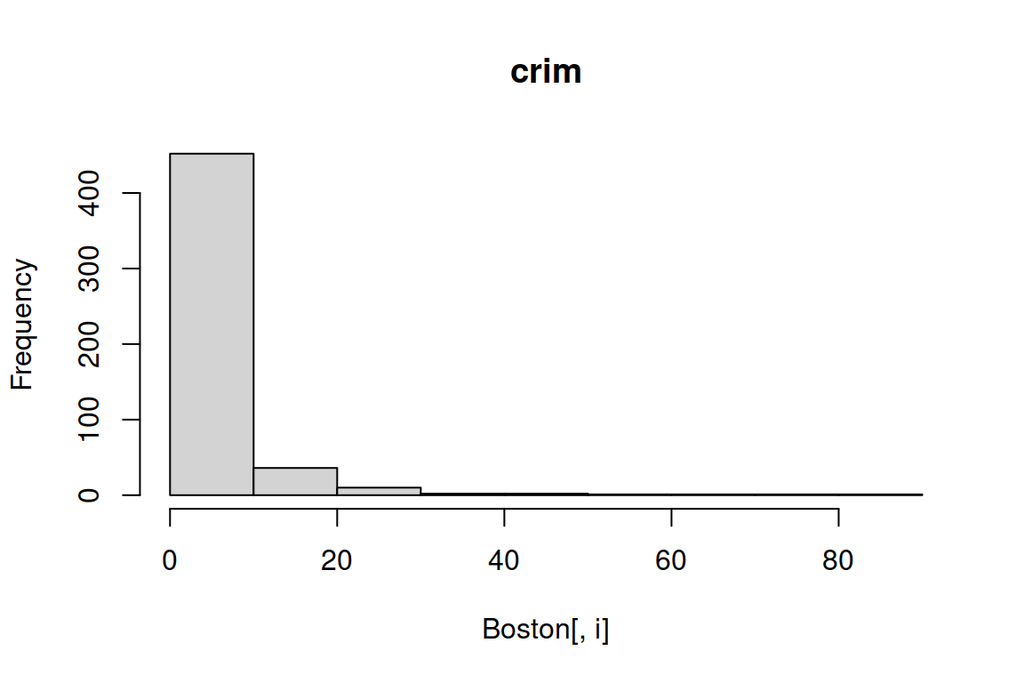

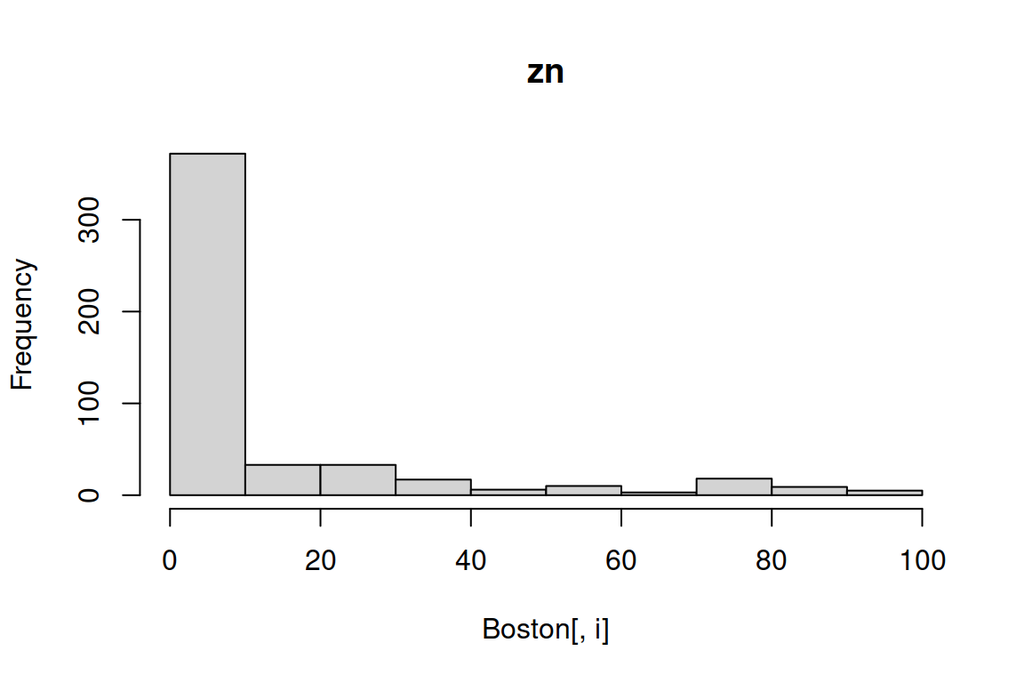

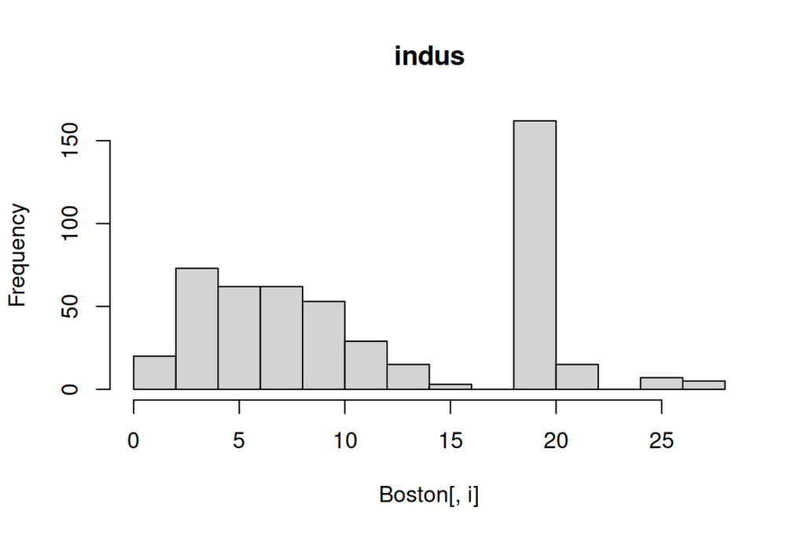

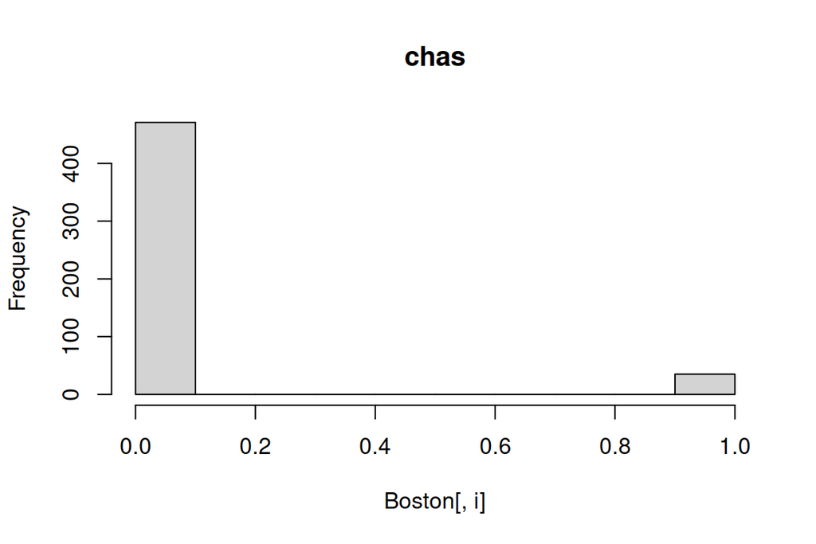

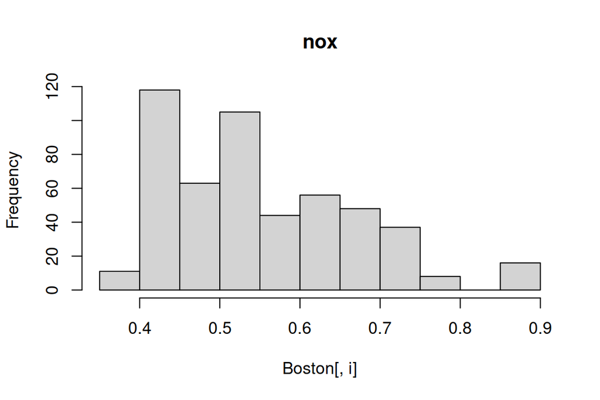

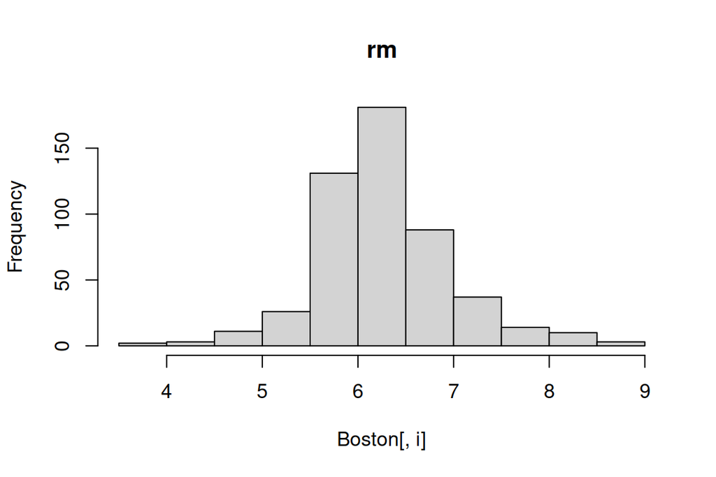

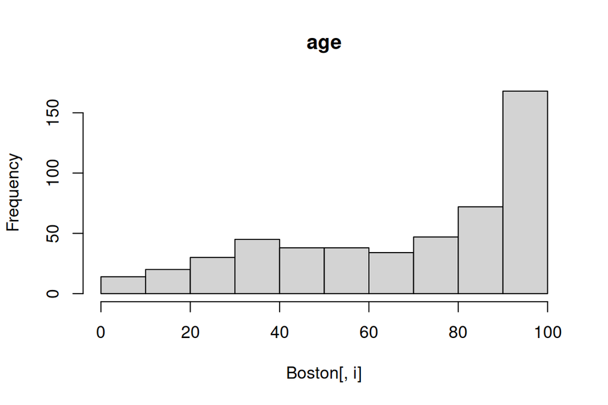

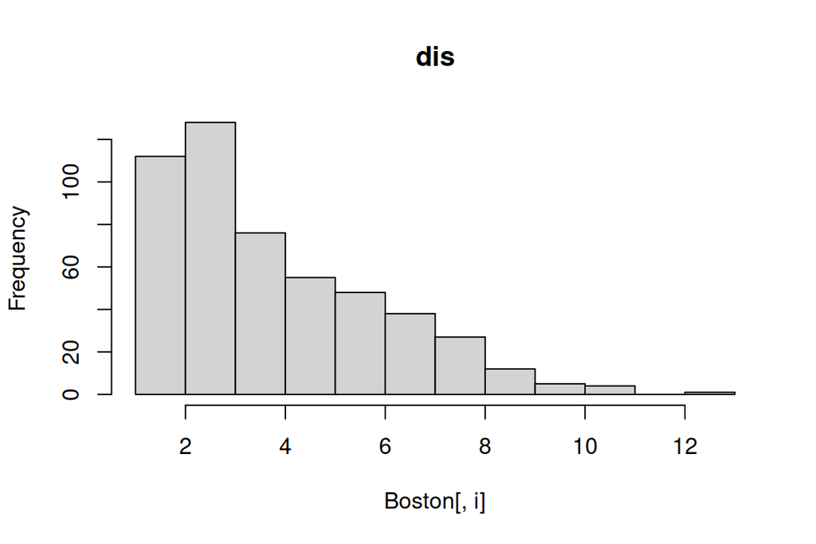

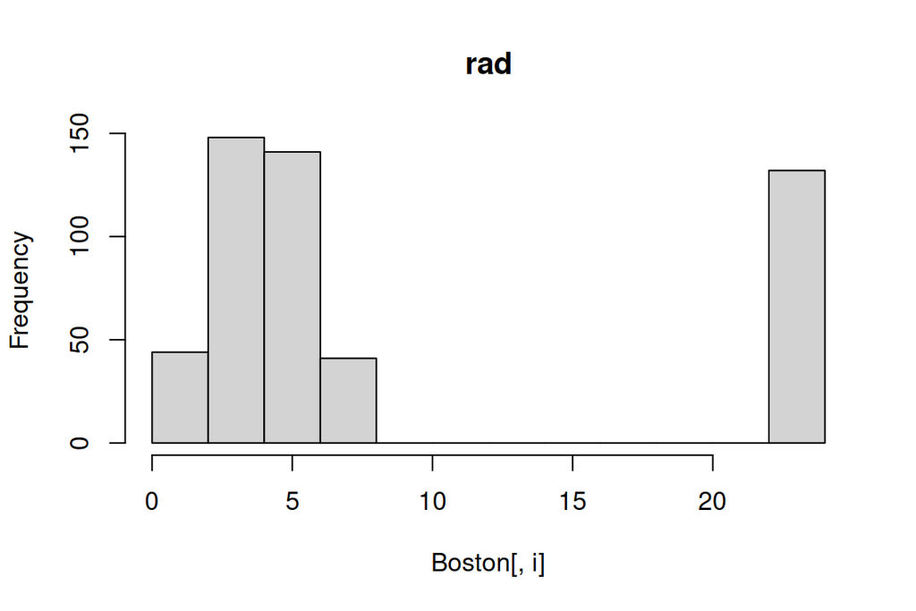

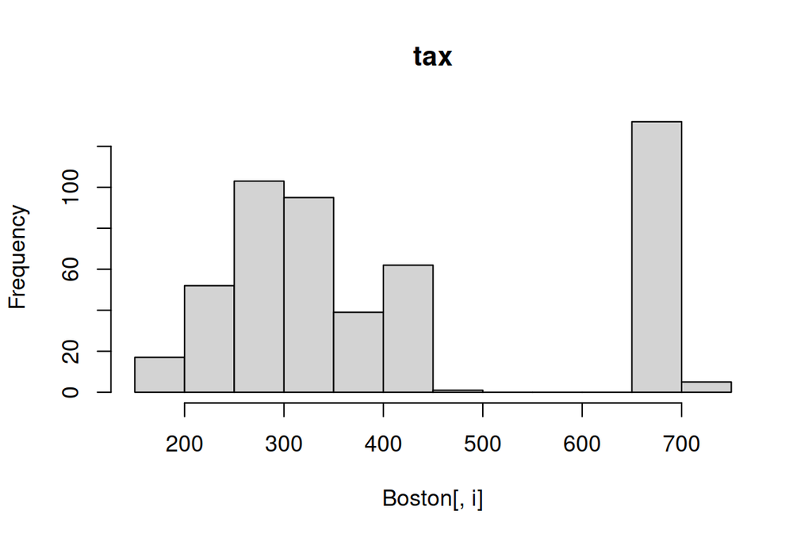

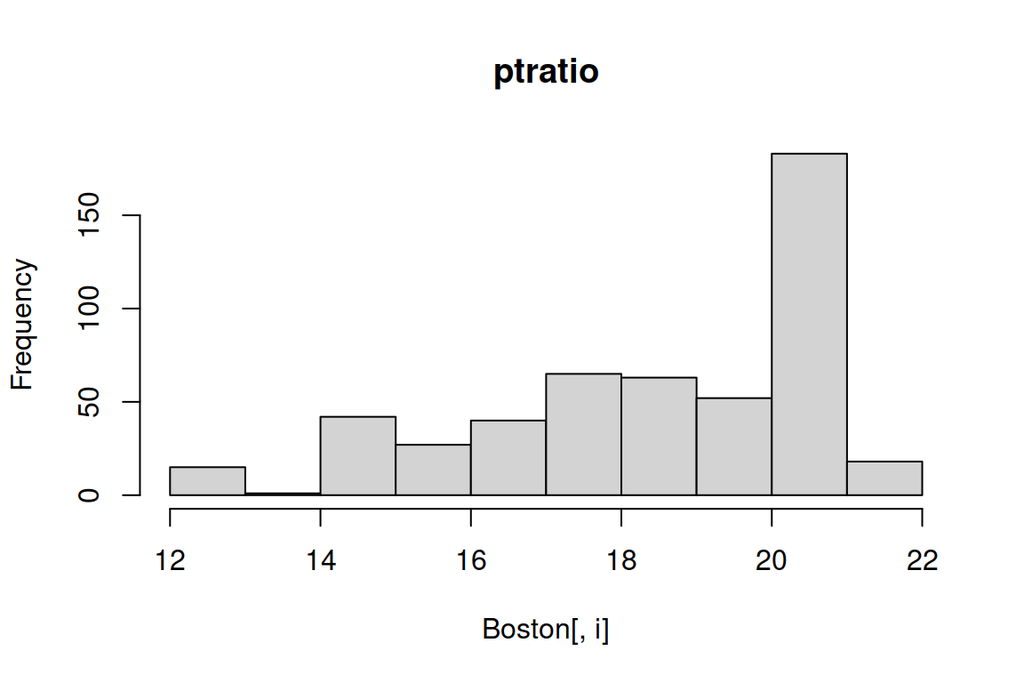

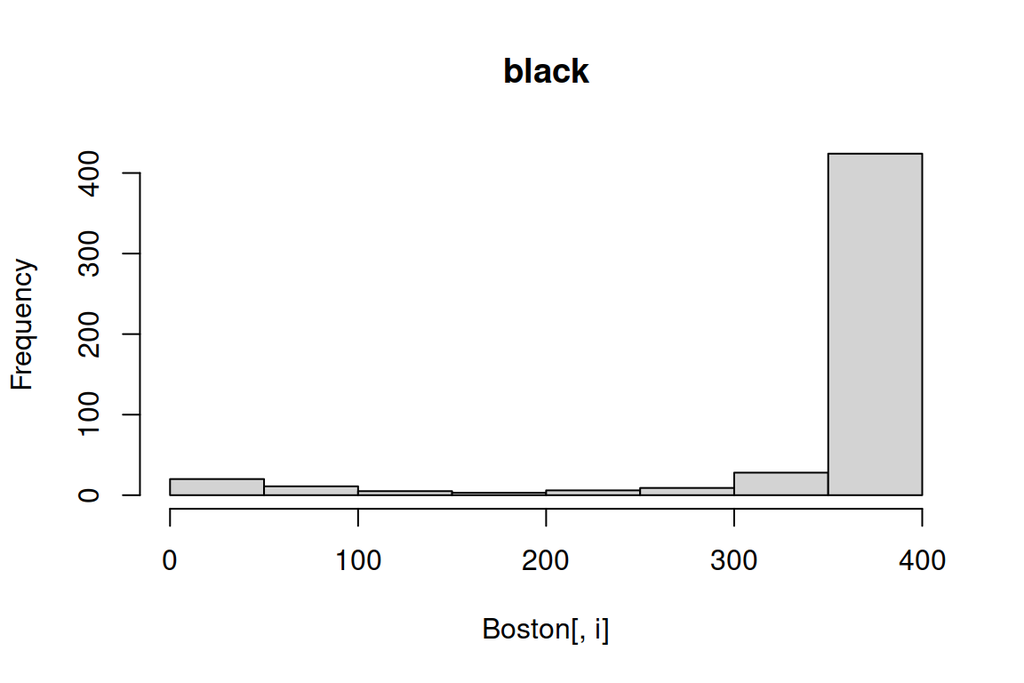

[2 more figures not shown]

```r
for(i in 1:14){
  hist(Boston[,i], main=colnames(Boston)[i])
}
```

Unsurprisingly, many of the variables describing the areas have strong correlations with each other. For example the amount of air pollution (nox) and the amount of industry (indus) have a strong positive correlation with each other and strong negative correlation with the distance to employment centres (dis). Property tax rate has a strong positive correlation with accessibility to radial highways. Median value of homes has again unsurprisingly a negative correlation with many variables such as crime rate, amount of industry, proportion of old buildings, tax rate and pupil-to-teacher ratio and a positive correlation with average number of rooms per dwelling. Many variables such as accessibility to radial highways (rad), property tax rate per $10,000 (tax) and amount of industry (indus) seem to have a high number of extreme values and distributions are very uneven.

```r
for(i in 1:14){
  Boston[,i] = (Boston[,i]-mean(Boston[,i]))/(sd(Boston[,i]))
}
summary(Boston)
```

```
##       crim                 zn               indus              chas
##  Min.   :-0.419367   Min.   :-0.48724   Min.   :-1.5563   Min.   :-0.2723
##  1st Qu.:-0.410563   1st Qu.:-0.48724   1st Qu.:-0.8668   1st Qu.:-0.2723
##  Median :-0.390280   Median :-0.48724   Median :-0.2109   Median :-0.2723
##  Mean   : 0.000000   Mean   : 0.00000   Mean   : 0.0000   Mean   : 0.0000
##  3rd Qu.: 0.007389   3rd Qu.: 0.04872   3rd Qu.: 1.0150   3rd Qu.:-0.2723
##  Max.   : 9.924110   Max.   : 3.80047   Max.   : 2.4202   Max.   : 3.6648
##       nox                rm               age               dis
##  Min.   :-1.4644   Min.   :-3.8764   Min.   :-2.3331   Min.   :-1.2658
##  1st Qu.:-0.9121   1st Qu.:-0.5681   1st Qu.:-0.8366   1st Qu.:-0.8049
##  Median :-0.1441   Median :-0.1084   Median : 0.3171   Median :-0.2790
##  Mean   : 0.0000   Mean   : 0.0000   Mean   : 0.0000   Mean   : 0.0000
##  3rd Qu.: 0.5981   3rd Qu.: 0.4823   3rd Qu.: 0.9059   3rd Qu.: 0.6617
##  Max.   : 2.7296   Max.   : 3.5515   Max.   : 1.1164   Max.   : 3.9566
##       rad               tax             ptratio            black
##  Min.   :-0.9819   Min.   :-1.3127   Min.   :-2.7047   Min.   :-3.9033
##  1st Qu.:-0.6373   1st Qu.:-0.7668   1st Qu.:-0.4876   1st Qu.: 0.2049
##  Median :-0.5225   Median :-0.4642   Median : 0.2746   Median : 0.3808
##  Mean   : 0.0000   Mean   : 0.0000   Mean   : 0.0000   Mean   : 0.0000
##  3rd Qu.: 1.6596   3rd Qu.: 1.5294   3rd Qu.: 0.8058   3rd Qu.: 0.4332
##  Max.   : 1.6596   Max.   : 1.7964   Max.   : 1.6372   Max.   : 0.4406
##      lstat              medv
##  Min.   :-1.5296   Min.   :-1.9063
##  1st Qu.:-0.7986   1st Qu.:-0.5989
##  Median :-0.1811   Median :-0.1449
##  Mean   : 0.0000   Mean   : 0.0000
##  3rd Qu.: 0.6024   3rd Qu.: 0.2683
##  Max.   : 3.5453   Max.   : 2.9865
```

```r
# Categorize crime variable
Boston$crime <- cut(Boston$crim, breaks=quantile(Boston$crim)+ c(-0.1, 0, 0, 0, 0.1), labels=c("1st","2nd","3rd", "4th"))
Boston = subset(Boston, select = -c(crim))
# Train and test split
set.seed(68)
idxs = sample(1:506)
train_idxs = idxs[1:floor(0.8*nrow(Boston))]
test_idxs = idxs[ceiling(0.8*nrow(Boston)):nrow(Boston)]
Boston_train = Boston[train_idxs,]
Boston_test = Boston[test_idxs,]
```

The data set is standardized so that each variable has zero mean and unit variance, which makes the values of different variables more comparable with each other. (Standardizing might also mean that all values are scaled between 0 and 1 but I hope that this is what was asked for..).

```r
library(ggordiplots)
model <- lda(crime~., Boston_train)
model
```

```
## Call:
## lda(crime ~ ., data = Boston_train)
##
## Prior probabilities of groups:
##       1st       2nd       3rd       4th
## 0.2450495 0.2524752 0.2524752 0.2500000
##
## Group means:
##             zn      indus        chas        nox         rm        age
## 1st  0.9541246 -0.9179094 -0.11325431 -0.8787664  0.4175470 -0.8910834
## 2nd -0.1002950 -0.3020788  0.03646311 -0.5895328 -0.1271396 -0.3749115
## 3rd -0.3846714  0.1060492  0.22945822  0.3125426  0.1141711  0.3358754
## 4th -0.4872402  1.0171306 -0.07742312  1.0401716 -0.4557229  0.8023591
##            dis        rad        tax    ptratio      black       lstat
## 1st  0.8986948 -0.6837338 -0.7429037 -0.4157047  0.3772614 -0.75752434
## 2nd  0.3803870 -0.5404996 -0.4988248 -0.1261836  0.3184573 -0.10655368
## 3rd -0.3166826 -0.3749852 -0.3128530 -0.3068701  0.1069363 -0.03630269
## 4th -0.8495458  1.6379981  1.5139626  0.7806252 -0.7317945  0.83319644
##            medv
## 1st  0.48670587
## 2nd  0.03374224
## 3rd  0.18703005
## 4th -0.63215490
##
## Coefficients of linear discriminants:
##                   LD1         LD2         LD3
## zn       0.1039744838  0.84004371 -0.83888709
## indus    0.0179511066 -0.39656444  0.44146240
## chas    -0.0750134144 -0.05114308  0.08258993
## nox      0.3921905425 -0.58047867 -1.52220582
## rm      -0.0822532395 -0.09723577 -0.13371454
## age      0.2700962412 -0.24181903 -0.23508224
## dis     -0.0865315391 -0.23737894  0.13493175
## rad      2.9674925392  0.71749458  0.14158831
## tax      0.0005257643  0.16931766  0.40058481
## ptratio  0.1231025753  0.12306259 -0.31398652
## black   -0.1147154091 -0.01134012  0.10071234
## lstat    0.1670066563 -0.16002943  0.56454777
## medv     0.1444735530 -0.31543525 -0.08302376
##
## Proportion of trace:
##    LD1    LD2    LD3
## 0.9457 0.0391 0.0152
```

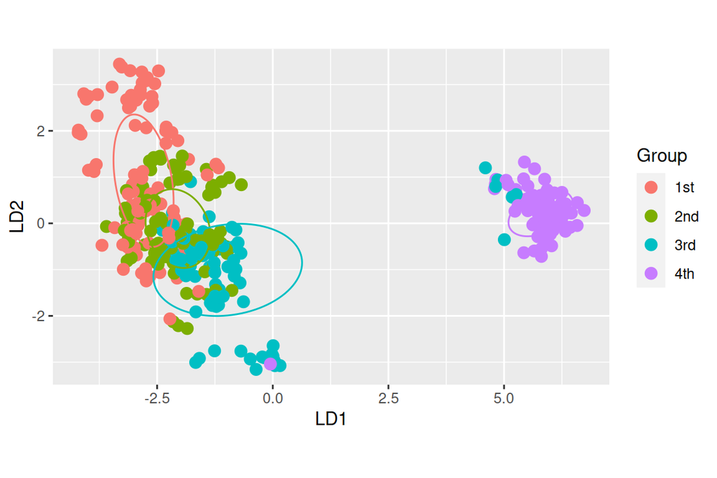

```r
gg_ordiplot(model, Boston_train$crime)
```

Seems that in the training data the model can separate the highest category from three lower ones, which get more mixed with each other.

```r
test_labels = Boston_test$crime
Boston_test = subset(Boston_test, select = -c(crime))
pred = predict(model, Boston_test)$class
table(Predicted = pred, Actual = test_labels)
```

```
##          Actual
## Predicted 1st 2nd 3rd 4th
##       1st  17   3   0   0
##       2nd  10  12   4   0
##       3rd   1   9  20   0
##       4th   0   0   0  26
```

The test results seem to follow the results of the biplot from training data. The hihgest category (4) is perfectly classified. Classes 3 and 1 get a little bit more mixed with class 2, and even half of all observations belonging to class 2 are incorrectly classified as either class 1 or 3. However, the results seem fairly good given that the categorization boundaries were quite arbitrary (the distribution of original response variable crime may not support the categorization into four even categories). The model seems to handle the order of the categories pretty well, since only one observation belonging to class 1 is classified more than one class away from the correct one.

I am a little bit confused what following problem statement means since I think this is what we exactly did in part 4: “Reload the Boston dataset and standardize the dataset (we did not do this in the Exercise Set, but you should scale the variables to get comparable distances).” However, here we go:

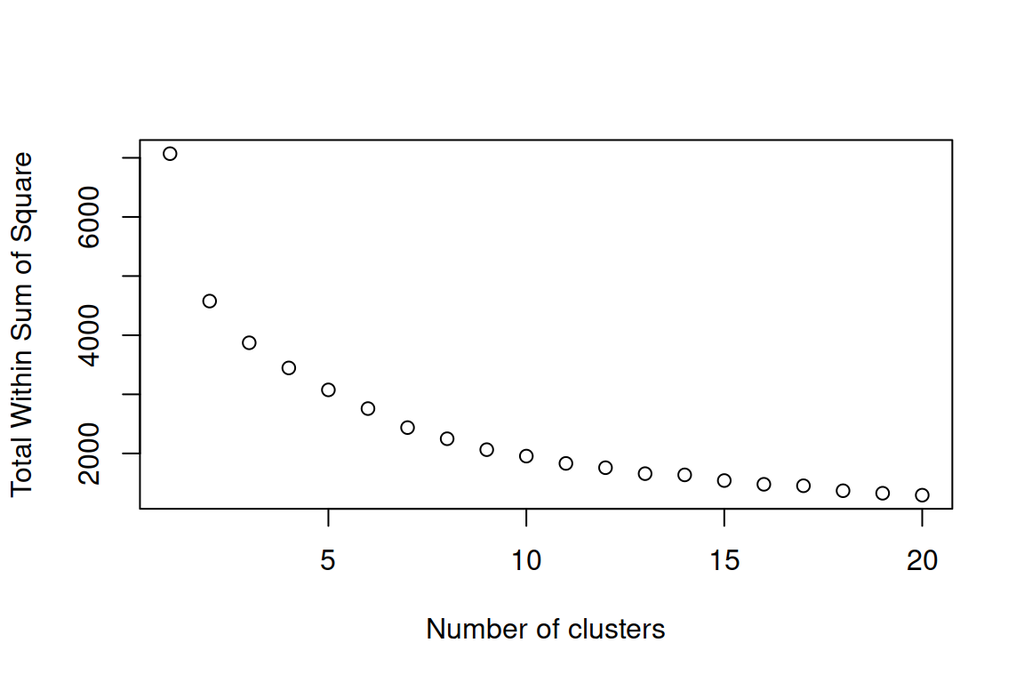

```r
data(Boston)
for(i in 1:14){
  Boston[,i] = (Boston[,i]-mean(Boston[,i]))/(sd(Boston[,i]))
}
# run clustering algorithm for 1-20 clusters and save the total sum of squares within cluster
ss = c()
for(k in 1:20){
  km = kmeans(Boston, centers = k, nstart = 25)
  ss = c(ss, km$tot.withinss)
}

plot(1:20, ss, main ="", ylab="Total Within Sum of Square", xlab="Number of clusters")
```

The smaller the sum of squares within the clusters indicates that the observations within the cluster are closer to each other and thus that the clustering is better. However, the TWSS will always get lower, when the number of clusters is increased but it is not reasonable to assign every single observation in its own cluster. We are thus looking for a point in the plot where the slope starts to get even. In this case it could be just two clusters, since after that every new cluster that we introduce decreases the TWSS but not very notably. Also the results from the lda would support two clusters. Let’s fit a new model with k=2 clusters and visualize the results.

[figure not shown]

```r
# fit new model
k2 = kmeans(Boston, centers = 2, nstart = 25)
# visualize clusters
pairs(Boston, col=k2$cluster)
```

It seems (when we zoom in to the picture) that our two clusters are very well separable and can be even interpreted as “good” and “bad” areas. The clusters clearly differ from each other in terms of crime rate, amount of industry, air pollution, taxation and closeness to highways.

Again, I unfortunately didn’t have time for Bonus exercises.. :’(

# Chapter 5

The analysis and results of week 5 are presented below.

```r
library(readr)
library(tidyverse)
library(psych)

human = read_csv('data/human.csv')
```

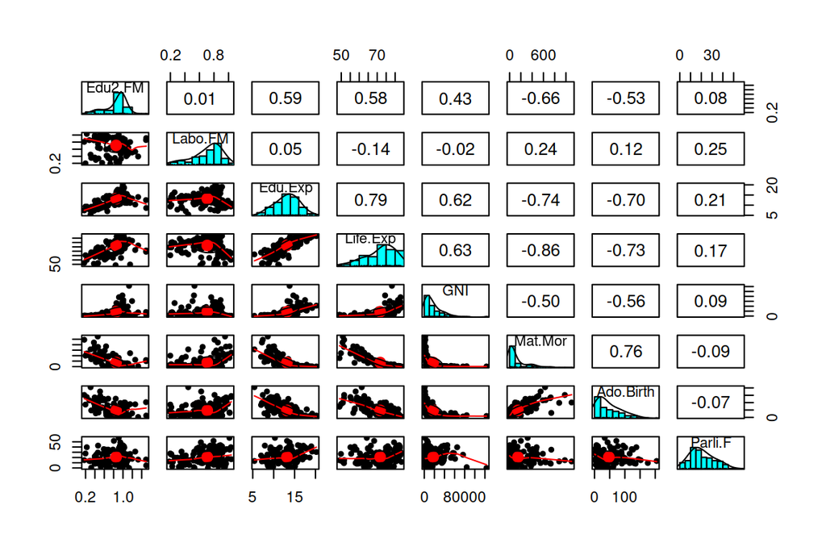

```r
human = human %>% remove_rownames %>% column_to_rownames(var="Country")
pairs.panels(human, method = "pearson", density = TRUE)
```

```r
pca = prcomp(human, scale =FALSE)
summary(pca)
```

```
## Importance of components:
##                              PC1      PC2   PC3   PC4   PC5   PC6    PC7    PC8
## Standard deviation     1.854e+04 185.5219 25.19 11.45 3.766 1.566 0.1912 0.1591
## Proportion of Variance 9.999e-01   0.0001  0.00  0.00 0.000 0.000 0.0000 0.0000
## Cumulative Proportion  9.999e-01   1.0000  1.00  1.00 1.000 1.000 1.0000 1.0000
```

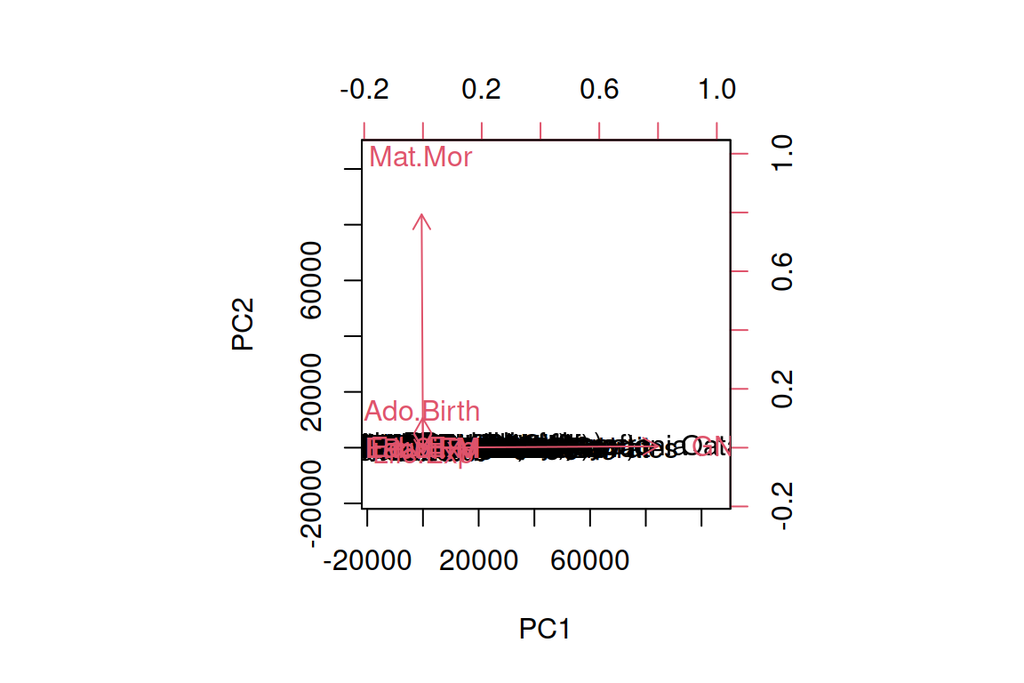

```r
biplot(pca, scale=0)
```

Two first principal components capture 100 % of the total variation. However, since the data is not normalized, the PCA analysis doesn’t produce very reliable results due to very different scales of different variables. Let’s repeat the analysis with normalized data:

```r
pca = prcomp(human, center=TRUE, scale =TRUE)
summary(pca)
```

```
## Importance of components:
##                           PC1    PC2     PC3     PC4     PC5     PC6     PC7
## Standard deviation     2.0708 1.1397 0.87505 0.77886 0.66196 0.53631 0.45900
## Proportion of Variance 0.5361 0.1624 0.09571 0.07583 0.05477 0.03595 0.02634
## Cumulative Proportion  0.5361 0.6984 0.79413 0.86996 0.92473 0.96069 0.98702
##                            PC8
## Standard deviation     0.32224
## Proportion of Variance 0.01298
## Cumulative Proportion  1.00000
```

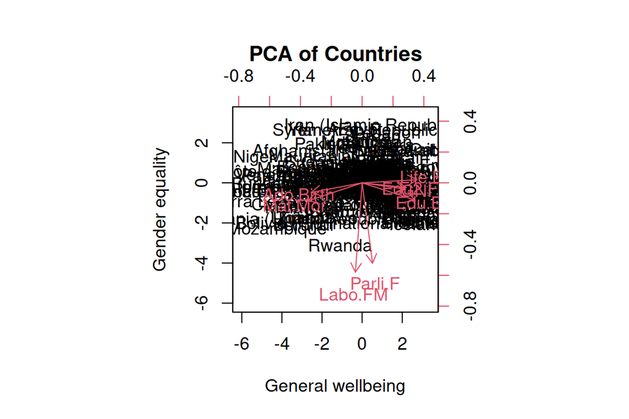

```r
biplot(pca, scale=0, xlab ='General wellbeing', ylab='Gender equality', main='PCA of Countries')
```

In the fixed PCA two first principal components explain close to 70% of all variation in the data. The first principal component describes roughly the general wellbeing (based on education, life expectancy, adolescent birth rate and maternal mortality) and second principal component the equality (the proportion of females in parliament and labour force). Proportion of females in secondary education compared to that of males should thematically fit better to the equality component but is in this analysis more aligned with overall wellbeing.

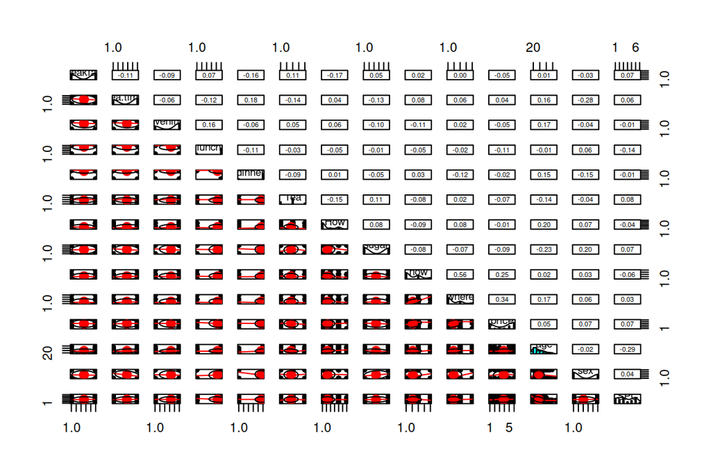

```r
tea <- read.csv("https://raw.githubusercontent.com/KimmoVehkalahti/Helsinki-Open-Data-Science/master/datasets/tea.csv", stringsAsFactors = TRUE)
View(tea)

# select a subset of fewer variables
tea = tea[c('breakfast', 'tea.time', 'evening', 'lunch', 'dinner', 'Tea', 'How', 'sugar', 'how', 'where', 'price', 'age', 'sex', 'SPC')]

pairs.panels(tea)
```

Unfortunately I could not install FactoMineR package due to some weird error so I could not complete the last exercise…

# Chapter 6

The analysis and results of week 6 are presented below. I only did the first exercise and I hope that I have done what I was supposed to do. I would have preferred a clear exercise statement that directly tells what we are asked to do instead of just repeating some random codes with different data sets. But anyway, here we go…

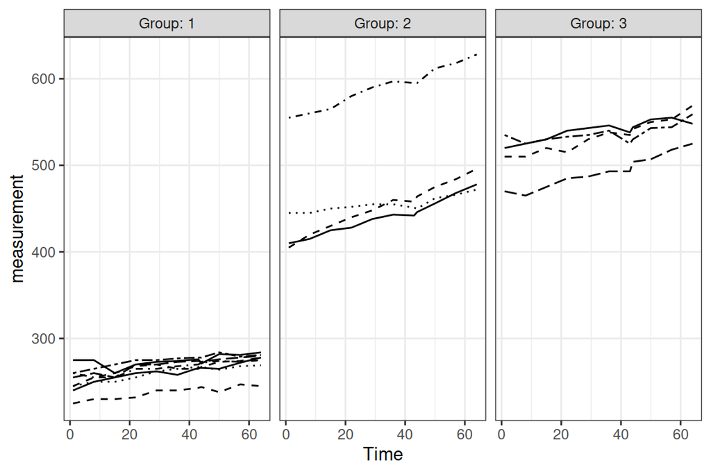

```r
# read and plot rat data
library(readr)
library(tidyverse)
library(ggplot2)

rats = read_csv('data/rats.csv')
rats$ID = factor(rats$ID)
rats$Group = factor(rats$Group)

for(d in c(1,8,15,22,29,36,43,44,50,57,64)){
  rats$Time[rats$Time== paste0('WD', d)] = d
}
rats$Time = as.numeric(rats$Time)

p1 <- ggplot(rats, aes(x = Time, y = measurement, linetype = ID))
p2 <- p1 + geom_line() + scale_linetype_manual(values = rep(1:8, times=4))
p3 <- p2 + facet_grid(. ~ Group, labeller = label_both)
p4 <- p3 + theme_bw() + theme(legend.position = "none")
p5 <- p4 + theme(panel.grid.minor.y = element_blank())
p6 <- p5 + scale_y_continuous(limits = c(min(rats$measurement), max(rats$measurement)))
print(p6)
```

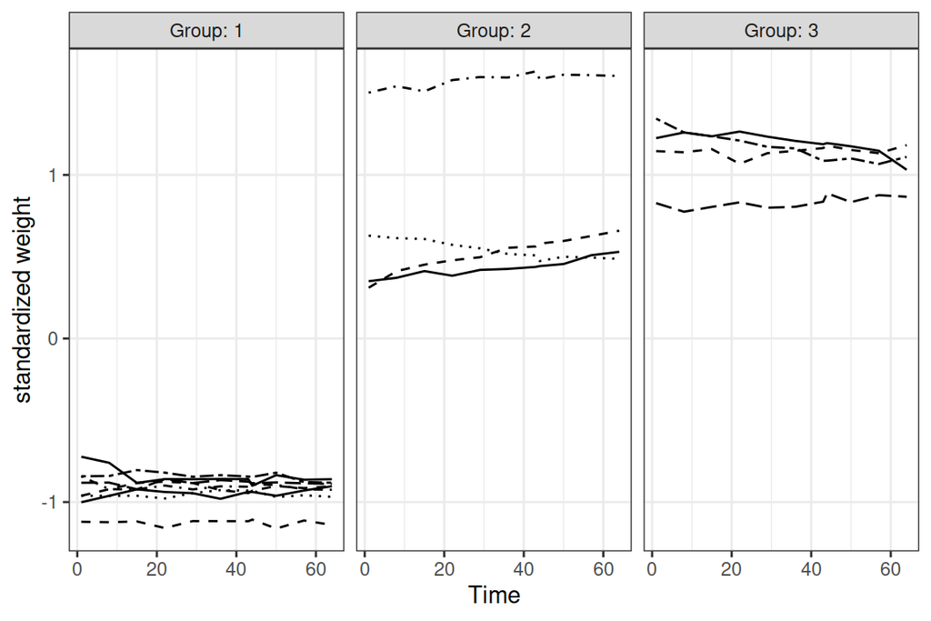

```r
# Standardise the scores:
rats <- rats %>%
  group_by(Time) %>%
  mutate( std_weight = (measurement - mean(measurement))/sd(measurement) ) %>%
  ungroup()

p1 <- ggplot(rats, aes(x = Time, y = std_weight, linetype = ID))
p2 <- p1 + geom_line() + scale_linetype_manual(values = rep(1:8, times=4))
p3 <- p2 + facet_grid(. ~ Group, labeller = label_both)
p4 <- p3 + theme_bw() + theme(legend.position = "none")
p5 <- p4 + theme(panel.grid.minor.y = element_blank())
p6 <- p5 + scale_y_continuous(name = "standardized weight")
print(p6)
```

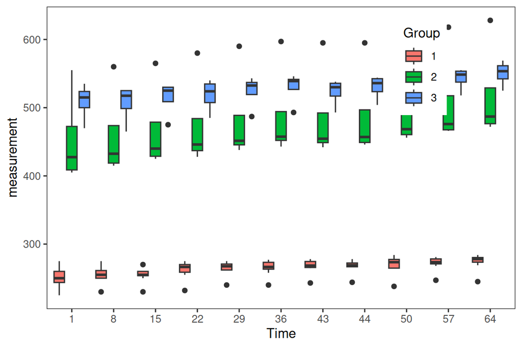

```r
p1 <- ggplot(rats, aes(x = factor(Time), y = measurement, fill = Group))
p2 <- p1 + geom_boxplot(position = position_dodge(width = 0.9))
p3 <- p2 + theme_bw() + theme(panel.grid.major = element_blank(), panel.grid.minor = element_blank())
p4 <- p3 + theme(legend.position = c(0.8,0.8))
p5 <- p4 + scale_x_discrete(name = "Time")
p5
```

All figures show that the rats in different treatment groups differ a lot from each other. Especially rats in group 1 were much smaller than other rats to begin with. All rats seem to have gained weight during the study.

```r
rats2 <- rats %>%
  filter(Time > 1) %>%
  group_by(Group, ID) %>%
  summarise( mean=mean(measurement) ) %>%
  ungroup()
```

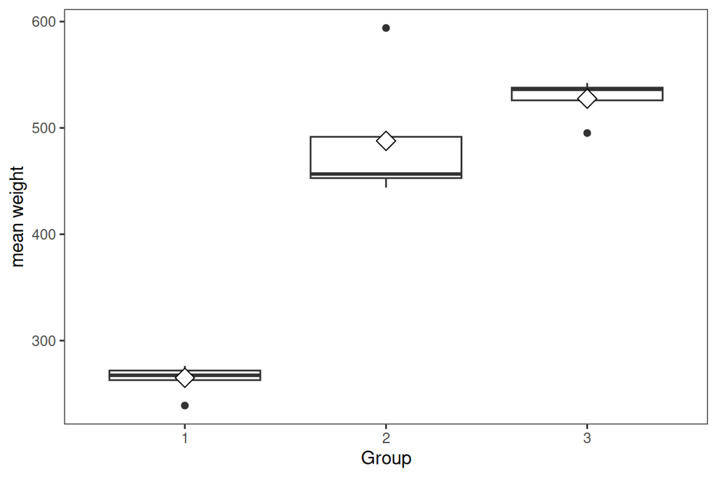

```r
p1 <- ggplot(rats2, aes(x = Group, y = mean))
p2 <- p1 + geom_boxplot()
p3 <- p2 + theme_bw() + theme(panel.grid.major = element_blank(), panel.grid.minor = element_blank())
p4 <- p3 + stat_summary(fun.y = "mean", geom = "point", shape=23, size=4, fill = "white")
p5 <- p4 + scale_y_continuous(name = "mean weight")
p5
```

In the textbook example some outliers were excluded at this point of analysis but I don’t think that this data set contains too weird outliers so we continue with the original data set.

```r
rats2a = rats2[rats2$Group!='1',]
t.test(mean ~ Group, data = rats2a, var.equal = TRUE)
```

```
##
##  Two Sample t-test
##
## data:  mean by Group
## t = -1.0686, df = 6, p-value = 0.3263
## alternative hypothesis: true difference in means between group 2 and group 3 is not equal to 0
## 95 percent confidence interval:
##  -130.60428   51.20428
## sample estimates:
## mean in group 2 mean in group 3
##           487.8           527.5
```

```r
rats2b = rats2[rats2$Group!='2',]
t.test(mean ~ Group, data = rats2b, var.equal = TRUE)
```

```
##
##  Two Sample t-test
##
## data:  mean by Group
## t = -27.824, df = 10, p-value = 8.345e-11
## alternative hypothesis: true difference in means between group 1 and group 3 is not equal to 0
## 95 percent confidence interval:
##  -283.4943 -241.4557
## sample estimates:
## mean in group 1 mean in group 3
##         265.025         527.500
```

```r
rats2c = rats2[rats2$Group!='3',]
t.test(mean ~ Group, data = rats2c, var.equal = TRUE)
```

```
##
##  Two Sample t-test
##
## data:  mean by Group
## t = -9.0646, df = 10, p-value = 3.88e-06
## alternative hypothesis: true difference in means between group 1 and group 2 is not equal to 0
## 95 percent confidence interval:
##  -277.5345 -168.0155
## sample estimates:
## mean in group 1 mean in group 2
##         265.025         487.800
```

As above plots and t-tests demonstrate, the rats in groups 2 and 3 were significantly bigger than rats in group 1. The differences between groups 2 and 3 are not statistically significant. However, the rats in those groups have been bigger already from the start, so I don’t think that this is a very meaningful or interesting result.

```r
# Add the baseline from the original data as a new variable to the summary data:

baseline <- rats$measurement[rats$Time==1]
rats3 <- rats2 %>%
  mutate(baseline)

# Fit the ANCOVA model and see the results:

fit <- lm(mean ~ baseline + Group, data = rats3)

summary(fit)
```

```
##
## Call:
## lm(formula = mean ~ baseline + Group, data = rats3)
##
## Residuals:
##     Min      1Q  Median      3Q     Max
## -23.905  -4.194   2.190   7.577  14.800
##
## Coefficients:
##             Estimate Std. Error t value Pr(>|t|)
## (Intercept) 33.16375   21.87657   1.516   0.1554
## baseline     0.92513    0.08572  10.793 1.56e-07 ***
## Group2      34.85753   18.82308   1.852   0.0888 .
## Group3      23.67526   23.25324   1.018   0.3287
## ---
## Signif. codes:  0 '***' 0.001 '**' 0.01 '*' 0.05 '.' 0.1 ' ' 1
##
## Residual standard error: 11.68 on 12 degrees of freedom
## Multiple R-squared:  0.9936, Adjusted R-squared:  0.992
## F-statistic: 622.1 on 3 and 12 DF,  p-value: 1.989e-13
```

```r
anova(fit)
```

```
## Analysis of Variance Table
##
## Response: mean
##           Df Sum Sq Mean Sq   F value   Pr(>F)
## baseline   1 253625  253625 1859.8201 1.57e-14 ***
## Group      2    879     439    3.2219  0.07586 .
## Residuals 12   1636     136
## ---
## Signif. codes:  0 '***' 0.001 '**' 0.01 '*' 0.05 '.' 0.1 ' ' 1
```

When we take the initial weight of the rats into account the diet is no longer a statistically significant explanatory variable for the weight of the rats. The differences in weights are mostly due to a large size difference already before the study.

I only did the first exercise.